# Statistical inference project part 2

c zingler

20/05/2020

# Overview

Part 2: Basic Inferential Data Analysis, Now in the second portion of the project, we’re going to analyze the ToothGrowth data in the R datasets package.

## Tasks

Load the ToothGrowth data and perform some basic exploratory data analyses.

Provide a basic summary of the data.

Use confidence intervals and/or hypothesis tests to compare tooth growth by supp and dose.

State your conclusions and the assumptions needed for your conclusions.

## Description

The tooth growth data set is the length of the odontoblasts (teeth) in each of 10 guinea pigs at three Vitamin C dosage levels (0.5, 1, and 2 mg) with two delivery methods (orange juice or ascorbic acid)

Citation from Google source RPubs

## Analysis

So the 10 guinea pigs are administered in two different ways, by delivery method, and by dose.

So we have two different Hypothyses.

hypothesis 1, delivery has an effect on growth.

hypothesis 2, dose has an effect on growth.

So we need to subset the toothgrowth data in the two categories to effectively test these hypothyses. We will use t tests to see if we can reject the null hypothesis in each category.

```r
library(datasets)
# so lets see what we are dealing with, and if we have pairing
dim(ToothGrowth)
```

```
## [1] 60  3
```

```r
head(ToothGrowth)
```

|  | len | supp | dose |
| --- | --- | --- | --- |
| 1 | 4.2 | VC | 0.5 |
| 2 | 11.5 | VC | 0.5 |
| 3 | 7.3 | VC | 0.5 |
| 4 | 5.8 | VC | 0.5 |
| 5 | 6.4 | VC | 0.5 |
| 6 | 10.0 | VC | 0.5 |

```r
table(ToothGrowth$supp)
```

```
##
## OJ VC
## 30 30
```

```r
table(ToothGrowth$dose)
```

```
##
## 0.5   1   2
##  20  20  20
```

So we will have one test for delivery as only two types to compare for group means and three tests for dose to compare the group means.

Let look at a box plot for delivery method.

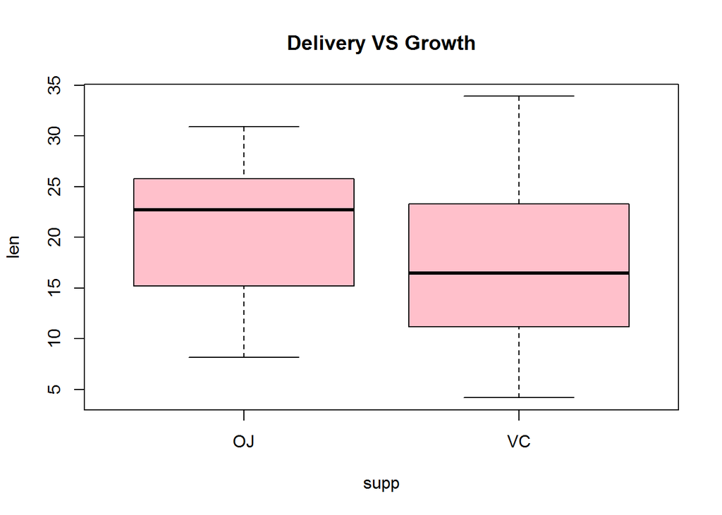

```r
#lets look at a box plot for Delivery method
boxplot(len~supp,ToothGrowth,main = "Delivery VS Growth", col= "pink")
```

Also lets look at the box plot for dose level

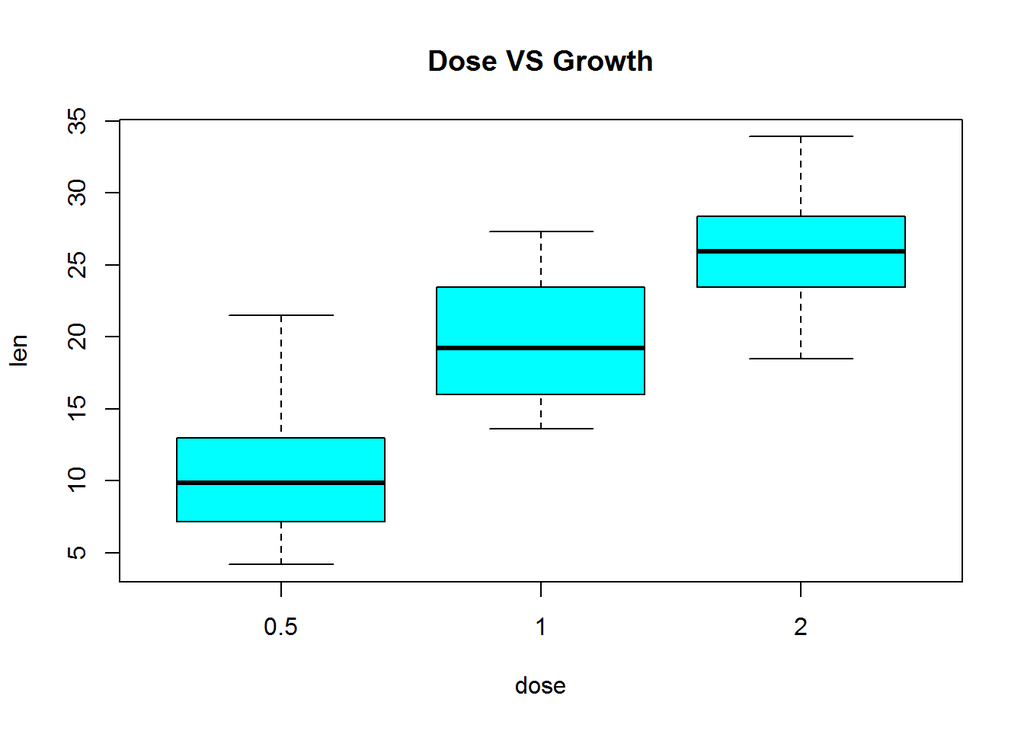

```r
#lets look at a box plot for Dosage level
boxplot(len~dose,ToothGrowth, main = "Dose VS Growth" , col= "cyan")
```

From inspection of the plots, there does not seem to be a case to reject hypothesis of no difference note the P-value is greater than 0.05, in results based on delivery method.

However there does seem to be a case to reject hypothesis of no difference based on dose.

let us check this with t tests..

Lets look at delivery method.

```r
# lets subset the data for delivery
g1 <- subset(ToothGrowth, supp== "OJ", select = c(len))
#and
 g2 <- subset(ToothGrowth, supp== "VC", select = c(len))

 #So lets do a Welch Two Sample t-test even though they are the same subjects we can not
 # Guarantee the elements are paired.

 t.test(g1,g2)
```

```
##
##  Welch Two Sample t-test
##
## data:  g1 and g2
## t = 1.9153, df = 55.309, p-value = 0.06063
## alternative hypothesis: true difference in means is not equal to 0
## 95 percent confidence interval:
##  -0.1710156  7.5710156
## sample estimates:
## mean of x mean of y
##  20.66333  16.96333
```

From this we see that there is not enough evidence to reject the null hypothesis, that orange juice and ascorbic acid deliver the same growth.

Now we need to look at the dosage. So we need 3 subsets at the 0.5, 1.0, and 2.0 dose levels

```r
# lets subset the data.
d05 <- subset(ToothGrowth, dose== 0.5, select = c(len))
d10 <- subset(ToothGrowth, dose== 1.0, select = c(len))
d20 <- subset(ToothGrowth, dose== 2.0, select = c(len))

#so lets run the t tests
t.test(d05,d10)
```

```
##
##  Welch Two Sample t-test
##
## data:  d05 and d10
## t = -6.4766, df = 37.986, p-value = 1.268e-07
## alternative hypothesis: true difference in means is not equal to 0
## 95 percent confidence interval:
##  -11.983781  -6.276219
## sample estimates:
## mean of x mean of y
##    10.605    19.735
```

```r
t.test(d05,d20)
```

```
##
##  Welch Two Sample t-test
##
## data:  d05 and d20
## t = -11.799, df = 36.883, p-value = 4.398e-14
## alternative hypothesis: true difference in means is not equal to 0
## 95 percent confidence interval:
##  -18.15617 -12.83383
## sample estimates:
## mean of x mean of y
##    10.605    26.100
```

```r
t.test(d10,d20)
```

```
##
##  Welch Two Sample t-test
##
## data:  d10 and d20
## t = -4.9005, df = 37.101, p-value = 1.906e-05
## alternative hypothesis: true difference in means is not equal to 0
## 95 percent confidence interval:
##  -8.996481 -3.733519
## sample estimates:
## mean of x mean of y
##    19.735    26.100
```

So we have respective P-values d05/d10 = 1.268e-07 d05/d20 = 4.398e-14 d10/d20 = 1.906e-05

All are significantly small enough to indicate we reject the null hypothesis, have no impact on growth level. Clearly basded on these P-values they do.

I have assumed the subjects are not paired in the various subsets obtained.

# Conculsion

With this set of data.

There is no eveidence that the delivery method of vitamin C has a impact on increased tooth growth.

There is eveidence increasing the delivered dose increases tooth growth.